# FFTvalidation

Olalla Díaz-Yáñez

27/10/2021

## FFT implementation (updates from Hussain)

- Challenges FFTW software
- Buffer area is the half kernel size (different per species)
- It is faster indeed!

## Seed production

The number of seeds per cell is calculated as follow

$$S_{s,t} = N_{s,i,t} S_{max,s} d_{s,i}$$

where,

$S_{s,t}$ = max number of seeds $S_{s,t}$ produced by the trees of species s at time t

$N_{s,t,}$ = number of trees of that species in that cell

$S_{max,s}$ = = maximum fecundity per tree and year (user defined values available from table 1b n the supplement from Lischke.2006.

$d_{s}$ = a light availability function [0,1]. Here we have used the growth limitation factor estimated in LandClim light_rf(t) (name in LandClim manual) GetAvailableLightReductionFactor() (name in LandClim code). This is the main change compared to the TreeMig approach where they used instead a [0,1] value calculated with $\frac{lai_{s,i}}{lai_{s,max}}$ in relation to the current tree height and maximum tree height.

We discussed about including the seed mast period as a stochastic parameter in the past meeting, but so far it is not included.

## Seed dispersal

The exceptions are the same as before: If there is dispersal in one cell (x, y) for one species s it is first defined by:

$$\text{Dispersal}_{s, x, y}=
\begin{cases}
\text{TRUE}& \text{if there are no trees in the whole landscape} \\
\text{TRUE} & \text{if } B(BaseSeedProbability)>0\\
\text{TRUE} & \text{if }MD = NA \text{ and } B(MDm1Prob)>0\\
\text{TRUE} & \text{if }MD >= 500 \text{ and } B(MDm1Prob)>0\\
\end{cases}$$

where,

- BaseSeedProbability= BaseSeedProbabilityuser defined probability, default value = 0.001, it defines if seeds are available, due to background seed rain.
- MD = MaxDispersalDistance species specific
- E D= EffectiveDispersalDistance species specific
- EDm1Prob = EffectiveDm1Probabilityuser defined probability, default value = 0.1
- MDm1Prob = MaxDm1Probability user defined probability, default value = 0.01

Then the convolution *Number of seed X kernel dispersal proportion/probability* is calculated providing a map with the number of seeds per cell of each species in that year.

Currently all the cells that have at least 1 species become TRUE for regeneration.

## Spatial analysis

- Here I have run a simulations for single species
- The landscape is squared (landscape that)1500m x 1500m)
- There is no slope and the altitude is constant
- 200 years simulations
- Initially the landscape is empty except for a initial set of trees in the lower left corner
- The initial trees are 3 cohorts per cell of 3 different ages (10, 20, 30)
- The initial densities and biomass varied per species

### P. abies

Species characteristics:

- Age at Maturity= 50
- Max seed = 96500
- Dispersal distances:
  - EffectiveDispersalDistance = 70
  - MaxDispersalDistance = 250

Simulation species specific characteristics:

- Initial biomass per cohort for ages 10, 20 and 30 are 0.01, 0.0105 and 0.012.
- Initial number of stems per ha 1200 (distributed in the 3 initial cohorts)
- Altitude 1800m

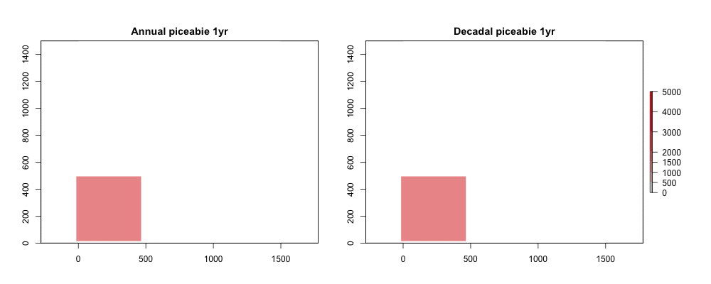

### F. sylvatica

Species characteristics:

- Age at Maturity= 60
- Max seed = 29000
- Dispersal distances:
  - EffectiveDispersalDistance = 30
  - MaxDispersalDistance = -1

Simulation species specific characteristics:

- Initial biomass per cohort for ages 10, 20 and 30 are 0.003 0.0035 and 0.004
- Initial number of stems per ha 1600 (distributed in the 3 initial cohorts) (I tried with higher but the trees died)
- Altitude 1200m

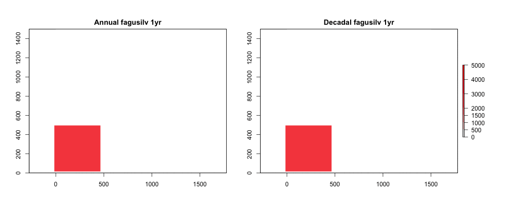

### B. pendula

Species characteristics:

- Age at Maturity= 20
- Max seeds = 11775000
- Dispersal distances:
  - EffectiveDispersalDistance = 200
  - MaxDispersalDistance = 700

Simulation species specific characteristics:

- Initial biomass per cohort for ages 10, 20 and 30 are 0.0122, 0.014 and 0.015
- Initial number of stems per ha 1600 (distributed in the 3 initial cohorts)
- Altitude 1000m

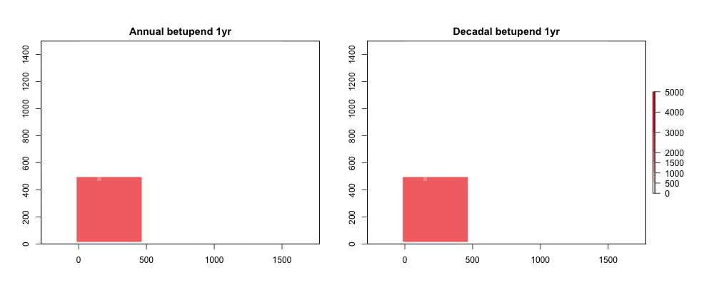

### P. sylvestris

Species characteristics:

- Age at Maturity= 30
- Max seed: 22000
- Dispersal distances:
  - EffectiveDispersalDistance = 90
  - MaxDispersalDistance = 300

Simulation species specific characteristics:

- Initial biomass per cohort for ages 10, 20 and 30 are 0.0114, 0.0116 and 0.0118
- Initial number of stems per ha 1800 (distributed in the 3 initial cohorts per cell)
- Altitude 900m

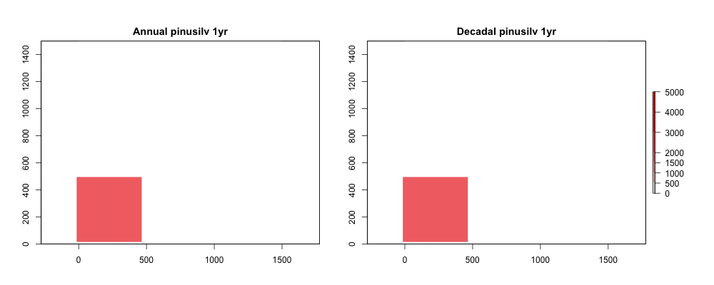

## TRUEs comparison

This compares the proportion of TRUEs per year in relation to the active cells in the landscape.

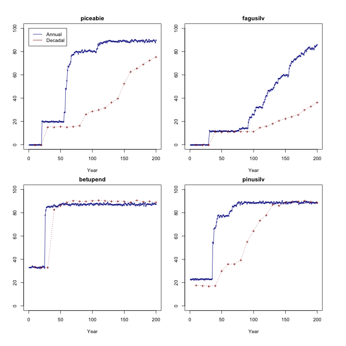